# Team 12: Nick Morgan, Antolín Moral Caballero, and Yejin Eun

- Problem statement and motivation
- Introduction and description of data
  - A revised project workflow based on the insights from EDA
  - Data wrangling prior to EDA
  - Exploratory Data Analysis
- Literature review / related work
- Modeling approach and project trajectory
  - The baseline model
  - Memory-Based Collaborative Filtering
  - Model-Based Collaborative Filtering
- Results
- Conclusions and Future Work

Note: We have hidden most of the code in the notebook and displayed important cells for better readability.

# Problem statement and motivation

Using user review data from Yelp, our aim was to develop a recommendation system to provide a new restaurant suggestion that a user might like. The project was motivated by the fact that recommendation problems are ubiquitious, including the infamous Netflix challenge and "similar items you might like" suggestions from Amazon. Given the diverse application of this problem, we wanted to learn how to develop and implement such system using machine learning. Below, we graphically illustrate our project goal.

[figure not shown]

back to top

# Introduction and description of data

[figure not shown]

Image credit: Yelp

The Yelp data is vast and rich: it contains millions of reviews of different business types (e.g. restaurants and dry cleaners), and each business type has different set of attributes associated with them. Each review at minimum consists of review text and review star rating. Because of its size and richness, it presented an initial challenge for us to decide what data to include in our modeling and what features should be engineered. In addition, not every user has made several reviews or reviews with different ratings, so we needed to figure out what datasets to use for training vs. testing. To this end, we performed EDA on the data, specifically to look at relevant business attributes, user attributes, and reviews. We reasoned that these are the core information needed to link users and businesses with their preferences (hence, we disregarded data such as checkin, photos, and tip).

## A revised project workflow based on the insights from EDA

We will use the cleaned datasets to accomplish three major goals:

1. Create a baseline estimate of a rating. This simple model will be created by recording the biases of each user and item to make a baseline estimate of a given user-item combination.
2. Create a regularized regression to improve the accuracy of our baseline model.
3. Use a Neighborhood model based on a item-to-item approach as a method of collaborative filtering to improve our model further. Our initial Neighborhood model will not include features of the restaurant, but rather, similarities between restaurants based on the users that have reviewed it.

back to top

## Data wrangling prior to EDA

### Converting JSON files to CSV

We downloaded a 5.6 GB TAR file from Yelp. This TAR file contained second TAR file that we extracted to get a series of JSON files: business, checkin, photos, review, tip, and user. Pandas has a read_json function, but it returned a Trailing Data Error when used on these specific files. As a result, we created a Python script that converts these JSON files into CSV files.

```python
def json_to_csv(directory, fileNames, createSample=False):
    """
    json_to_csv: loops through specified JSON files and converts them to csv files.
                 option to also create a sample csv, which uses np.random.seed 9001 to create a sample dataset with 10% of the observations

                 pandas has a read_json function, but returns a 'Trailing data error' when working with these specific files


    Inputs: -directory of JSON files
            -list of JSON filenames
            -createSample flag
    """

    start = time.time()

    jsonData = []

    for fileName in fileNames:
        with open(directory + fileName,  encoding="utf8") as file:
            print('{0} opened'.format(fileName))
            for line in file:
                #I use an rstrip here because some of the files have trailing blank spaces
                jsonData.append(json.loads(line.rstrip()))

        df = pd.DataFrame.from_dict(jsonData)

        csvFileName = fileName[:len(fileName)-5] + '.csv'

        df.to_csv(directory + csvFileName)
        print('{0} created'.format(csvFileName))


        if createSample:
            np.random.seed(9001)
            msk = np.random.rand(len(df)) <= 0.1
            sample = df[msk]

            csvSampleFileName = fileName[:len(fileName)-5] + '_sample.csv'

            sample.to_csv(directory + csvSampleFileName)
            print('{0} created'.format(csvSampleFileName))

    print('This function took {} minutes to run'.format((time.time()-start)/60))
```

### Keeping only "restaurant" business data and other associated data on users and reviews

- Only including reviews for businesses that existed in the reduced business (restaurant) dataset
- Only including reviews for users that have at least 2 reviews (A single rating does not help determine similarities between restaurants)

Number of businesses that have both "food" and "restaurant" in their category:

```python
# create a mask for restaurants
mask_restaurants = business['categories'].str.contains('Restaurants')

# create a mask for food
mask_food = business['categories'].str.contains('Food')

# apply both masks
restaurants_and_food = business[mask_restaurants & mask_food]

# number of businesses that have food and restaurant in their category
restaurants_and_food['categories'].count()
```

```
15502
```

Even after taking buisnesses that have both food and restaurant in their categories, there are still irrelevant business categories in the data.

```python
# an example row
restaurants_and_food.head(1)['categories'].values
```

```
array(["['Food', 'Soul Food', 'Convenience Stores', 'Restaurants']"], dtype=object)
```

Thus, we manually identified additional categories that needed to be excluded specifically.

```python
categoriesToRemove = ['Grocery','Drugstores','Convenience Stores','Beauty & Spas','Photography Stores & Services',
                      'Cosmetics & Beauty Supply','Discount Store','Fashion','Department Stores','Gas Stations',
                      'Automotive','Music & Video','Event Planning & Services','Mobile Phones','Health & Medical',
                      'Weight Loss Centers','Home & Garden','Kitchen & Bath','Jewelry',"Children's Clothing",
                      'Accessories','Home Decor','Bus Tours','Auto Glass Services','Auto Detailing',
                      'Oil Change Stations', 'Auto Repair','Body Shops','Car Window Tinting','Car Wash',
                      'Gluten-Free','Fitness & Instruction','Nurseries & Gardening','Wedding Planning',
                      'Embroidery & Crochet','Dance Schools','Performing Arts',
                      'Wholesale Stores','Tobacco Shops','Nutritionists','Hobby Shops','Pet Services',
                      'Electronics','Plumbing','Gyms','Yoga','Walking Tours','Toy Stores','Pet Stores',
                      'Pet Groomers','Vape Shops','Head Shops',
                      'Souvenir Shops','Pharmacy','Appliances & Repair','Wholesalers','Party Equipment Rentals',
                      'Tattoo','Funeral Services & Cemeteries','Sporting Goods','Dog Walkers',
                      'Pet Boarding/Pet Sitting','Scavenger Hunts','Contractors','Trainers',
                      'Customized Merchandise', 'Dry Cleaning & Laundry', 'Art Galleries'
                      'Tax Law', 'Bankruptcy Law', 'Tax Services', 'Estate Planning Law',
                      'Business Consulting', 'Lawyers', 'Pet Adoption', 'Escape Games',
                      'Animal Shelters', 'Commercial Real Estate', 'Real Estate Agents',
                      'Real Estate Services', 'Home Inspectors']
```

### Expanding business attributes & categories

After cleaning the business dataset, we expanded the attributes into boolean features. The attributes were a collection of a string of a dictionary. We evaluated this string as a dictionary and applied pd.Series across the result, which expanded this dictionary into multiple Boolean columns, as well as a few more dictionary columns. All remaining dictionary columns were manipulated in the same manner, leaving us ~70 Boolean columns. The business dataset also had a variable, categories, that was a string of a list. We expanded this list into separate columns for each category. Lastly, we then reduced our user dataset by filtering to users that existed in the reduced review dataset. The following functions were used for this process.

```python
#create_attributes

#takes a dataframe as an input, as well as a list of columns that are dictionaries
#takes each column that is a dictionary, and expands it into a series of dummy columns

def create_attributes(df, dictList):

    for dictionaryColumn in dictList:

        #the attributes column is a string of dictionaries, so one extra step is taken to convert
        if dictionaryColumn == 'attributes':
            expandedColumns = df[dictionaryColumn].map(eval).apply(pd.Series)
        else:
            expandedColumns = df[dictionaryColumn].apply(pd.Series)

        df = pd.concat([df.drop(dictionaryColumn,axis=1),
                   expandedColumns]
                  ,axis=1)

        #df.fillna(value='{}',inplace=True)

    return df
```

```python
def expand_categories(df, cat_var, key):
    all_cats = df[cat_var].str.cat(sep=', ')
    all_cats = all_cats.replace('[', '')
    all_cats = all_cats.replace(']', '')
    all_cats = all_cats.replace("\'","")
    all_cats = all_cats.replace('"','')
    all_cats_list = all_cats.split(', ')
    unique_cats = list(set(all_cats_list))
    unique_cats.remove('Restaurants')
    unique_cats.remove('Food')
    df_cats = pd.DataFrame(index=df[key], columns=unique_cats, data=False)
    df_out = df.merge(df_cats, how='left', left_on=key, right_index=True)
    for cat in unique_cats:
        df_out[cat] = df_out[cat_var].str.contains(cat)
    return df_out
```

Before expansion:

```python
restaurants_df.head(1)
```

|  | address | attributes | average_stars | business_id | categories | city | compliment_cool | compliment_cute | compliment_funny | compliment_hot | ... | longitude | name | neighborhood | postal_code | review_count | stars | state | useful | user_id | yelping_since |
| --- | --- | --- | --- | --- | --- | --- | --- | --- | --- | --- | --- | --- | --- | --- | --- | --- | --- | --- | --- | --- | --- |
| 1183396 | 30 High Tech Rd | {'HasTV': True, 'Caters': False, 'RestaurantsA... | NaN | reWc1g65PNZnKz_Ub9QKOQ | ['Comfort Food', 'Canadian (New)', 'Restaurant... | Richmond Hill | NaN | NaN | NaN | NaN | ... | -79.429343 | Milestones Restaurants | NaN | L4B 4L9 | 51 | 2.5 | ON | NaN | NaN | NaN |

1 rows × 35 columns

After expansion:

```python
expanded.head(1)
```

|  | business_id | AgesAllowed | Alcohol | BYOB | BYOBCorkage | BikeParking | BusinessAcceptsBitcoin | BusinessAcceptsCreditCards | ByAppointmentOnly | Caters | ... | karaoke | live | no_music | video | breakfast | brunch | dessert | dinner | latenight | lunch |
| --- | --- | --- | --- | --- | --- | --- | --- | --- | --- | --- | --- | --- | --- | --- | --- | --- | --- | --- | --- | --- | --- |
| 1183396 | reWc1g65PNZnKz_Ub9QKOQ | NaN | full_bar | NaN | NaN | True | NaN | True | NaN | False | ... | False | False | False | False | False | True | True | False | False | False |

1 rows × 67 columns

After cleaning up the business data, we kept relevant review and user data only.

```python
def reduce_review(df, business_list):

    #drop columns where business_id or user_id is null
    df.dropna(subset=['business_id','user_id'], how='any',inplace=True)

    #restrict to businesses that are restaurants
    df = df[df['business_id'].isin(business_list)]

    #only keep user_id's with more than one review
    df = df[df.groupby('user_id').user_id.transform(len) > 1]

    #verify this worked by taking the minimum amount of user_id counts
    print('The minimum amount of reviews per user is {}'
          .format(np.min(df.groupby('user_id')['business_id'].count())))
    return df
```

```python
restaurant_reviews.head()
```

|  | business_id | review_cool | review_funny | review_id | review_stars | review_useful | user_id | review_year | review_month | review_weekday |
| --- | --- | --- | --- | --- | --- | --- | --- | --- | --- | --- |
| 293 | MKd_EUD0PG__cOfIbeqYAg | 0 | 0.0 | ABeny93AMSYm7Hn8UXPrRQ | 5.0 | 1.0 | 3KkT6SmPFLGvBS1pnDBr8g | 2011 | 12 | Tuesday |
| 294 | MKd_EUD0PG__cOfIbeqYAg | 1 | 1.0 | KiGRD0ZhuDF1K1xLc0jjGA | 4.0 | 2.0 | TsBUWbhRhuiEMXb56kL0Cg | 2012 | 11 | Thursday |
| 295 | MKd_EUD0PG__cOfIbeqYAg | 0 | 0.0 | nGV40rXMRL_IN6lWpyrsmA | 4.0 | 0.0 | Um2iec4NKMXVpJEME3PfKg | 2008 | 1 | Thursday |
| 296 | MKd_EUD0PG__cOfIbeqYAg | 10 | 8.0 | 8FvVPvTaMJAM5drD18JxAA | 4.0 | 14.0 | 135DbbQnr3BEkQbBzZ9T1A | 2015 | 2 | Tuesday |
| 297 | MKd_EUD0PG__cOfIbeqYAg | 0 | 0.0 | CBamcMDNj6fCU5JbkRFgfw | 4.0 | 0.0 | 3ew6BEeK14K6x6Omt5gbig | 2017 | 5 | Monday |

```python
users_w_reviews.head(1)
```

|  | user_average_stars | user_compliment_cool | user_compliment_cute | user_compliment_funny | user_compliment_hot | user_compliment_list | user_compliment_more | user_compliment_note | user_compliment_photos | user_compliment_plain | ... | user_compliment_writer | user_cool | user_fans | user_funny | user_review_count | user_useful | user_id | yelping_since | user_elite_flag | user_friends_flag |
| --- | --- | --- | --- | --- | --- | --- | --- | --- | --- | --- | --- | --- | --- | --- | --- | --- | --- | --- | --- | --- | --- |
| 0 | 3.8 | 5174 | 284 | 5174 | 5175 | 78 | 299 | 1435 | 7829 | 7397 | ... | 1834 | 16856 | 209 | 16605 | 272 | 17019 | lsSiIjAKVl-QRxKjRErBeg | 2010 | True | True |

1 rows × 21 columns

Then we finally merged all cleaned DFs.

```python
recommendations.head()
```

|  | business_id | review_cool | review_funny | review_id | review_stars | review_useful | review_year | review_month | review_weekday | average_stars | ... | user_compliment_profile | user_compliment_writer | user_cool | user_fans | user_funny | user_review_count | user_useful | yelping_since_y | user_elite_flag | user_friends_flag |
| --- | --- | --- | --- | --- | --- | --- | --- | --- | --- | --- | --- | --- | --- | --- | --- | --- | --- | --- | --- | --- | --- |
| 0 | MKd_EUD0PG__cOfIbeqYAg | 0 | 0.0 | ABeny93AMSYm7Hn8UXPrRQ | 5.0 | 1.0 | 2011 | 12 | Tuesday | NaN | ... | 1 | 10 | 45 | 16 | 54 | 214 | 94 | 2009 | True | True |
| 1 | MKd_EUD0PG__cOfIbeqYAg | 1 | 1.0 | KiGRD0ZhuDF1K1xLc0jjGA | 4.0 | 2.0 | 2012 | 11 | Thursday | NaN | ... | 0 | 31 | 19 | 13 | 18 | 197 | 27 | 2011 | True | True |
| 2 | MKd_EUD0PG__cOfIbeqYAg | 0 | 0.0 | nGV40rXMRL_IN6lWpyrsmA | 4.0 | 0.0 | 2008 | 1 | Thursday | NaN | ... | 1 | 1 | 1 | 2 | 3 | 36 | 10 | 2008 | False | True |
| 3 | MKd_EUD0PG__cOfIbeqYAg | 10 | 8.0 | 8FvVPvTaMJAM5drD18JxAA | 4.0 | 14.0 | 2015 | 2 | Tuesday | NaN | ... | 31 | 264 | 1284 | 120 | 1130 | 578 | 1288 | 2010 | True | True |
| 4 | MKd_EUD0PG__cOfIbeqYAg | 0 | 0.0 | CBamcMDNj6fCU5JbkRFgfw | 4.0 | 0.0 | 2017 | 5 | Monday | NaN | ... | 0 | 0 | 0 | 0 | 0 | 81 | 4 | 2014 | True | True |

5 rows × 432 columns

back to top

## Exploratory Data Analysis

### Most users have only a few number of reviews.

Most users have only 1, 2 or 3 reviews (90% of users have less than 10 reviews) and the average stars per user (including all type of business, not restricted to restaurants) is 3.75. This indicates that a final matrix with users and businesses will be a sparse matrix. It may be difficult to give recommendations to users that don’t review many restaurants, especially if those restaurants don’t have many reviews. Further, there are 2,373 users that rate everything as 1, which will make recommendations difficult as we do not have data of anything they like so we won’t make recommendations for those users.

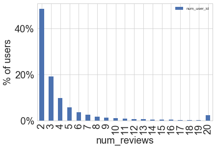

```python
num_reviews_per_var(reviews, 'user_id', 'review_id', 20, 'num_reviews', '% of users')
```

### User bias: some users tend to give higher ratings than others.

The histogram also shows differences in the average stars per user showing that some users tend to give higher ratings than others. These biases between users will be captured by our baseline model.

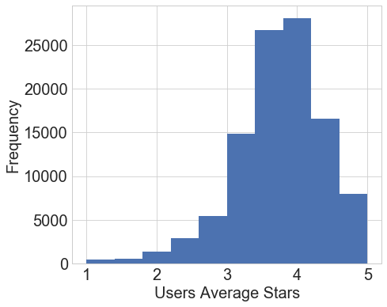

```python
fig, ax = plt.subplots(1,1, figsize=(7, 6))
users[y_user].plot(kind='hist', ax=ax)
ax.set_xlabel('Users Average Stars')
plt.show()
```

### Most businesses have more than 3 reviews.

Looking at business, the distribution of number of reviews per business is less ‘right-skewed’ and we have more restaurants with more than 3 reviews.

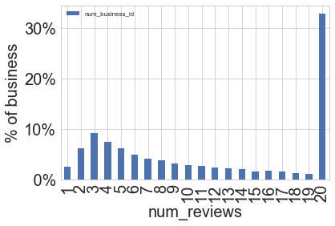

```python
num_reviews_per_var(reviews, 'business_id', 'review_id', 20, 'num_reviews', '% of business')
```

### Reducing the number of business categories

After expanding the business categories, we ended up with a dataframe of ~460 columns where each column was a distinct category. This number is too large, and we had to select categories that were more relevant to the goal of making recommendations to users. To find out which categories are most prominent and which are relevant for restaurant recommendation, we first got rid of the categories that only occur a few times in the dataset (the cutoff used was 11). These tended to be the ones not relevant to restaurants. Looking at the top 10 and bottom 10 categories in terms of number of occurrences, we found that the top 10 are mostly fast food or quick food places, and the bottom 10 are mostly ethnic food places. This gave us the idea that if two users like some of these rarely occurring restaurant categories, perhaps we could give them a greater weight when predicting/recommending the next restaurant.

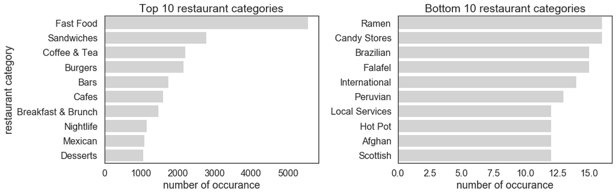

```python
fig, ax = plt.subplots(1, 2, figsize=(15, 5))
sns.barplot(x='count', y='category', data=num_busi_cat.head(10), color='lightgrey', ax=ax[0])
ax[0].set(ylabel='restaurant category')
ax[0].set(xlabel='number of occurance')
ax[0].set(title='Top 10 restaurant categories')
sns.barplot(x='count', y='category', data=num_busi_cat.tail(10), color='lightgrey', ax=ax[1])
ax[1].set(xlabel='number of occurance')
ax[1].set(title='Bottom 10 restaurant categories')
ax[1].set(ylabel='')
plt.tight_layout()
plt.show()
```

### Restaurant categories can be further reduced to a smaller set of dimensions.

After getting rid of the categories that only occur a few times in the dataset, we still had ~180 restaurant categories. While this number is smaller than the original we started with (~460), we sought to further reduce the number by performing dimensionality reduction (specifically, PCA). By doing so, we obtained the first 30 principal components that explained ~75% of the total variance in the data. Looking at the first 3 PCs for visualization, we found that the top three categories (fast food, sandwiches, and coffee & tea) are nicely clustering in these spaces. Given these results, we think that dimensionality reduction could be a useful way to incorporate many features related to restaurants for finding similar restaurants in the recommendation system.

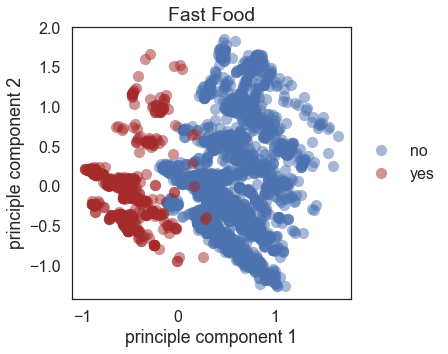

```python
feature_name = 'Fast Food'
plot_pca_results(0, 1, feature_name)
feature_name = 'Sandwiches'
plot_pca_results(1, 2, feature_name)
feature_name = 'Coffee & Tea'
plot_pca_results(0, 1, feature_name)
```